# BCB420 Assignment 1- Data set selection and initial processing

Angela Ng

# Introduction

Heart failure has a 5 year mortality rate of 50% and affects 6.5 million adult Americans. Despite technical and biological advances, later-stage heart failure with reduced ejection fraction (HFrEF) which have been shown to have diverse etiologies and genetic contributions, are still considered to evolve via a final common pathway. Current therapies are relatively indifferent to disease etiology and treat HFrEF due to ischemic cardiomyopathy (ICM) the same as dilated cardiomyopathy (DCM), even though ICM has a much worse prognosis than DCM. This can reflect an incomplete understanding of the different biological mechanisms contributing to HFrEF (Sweet et al. 2018).

This data set is from a study which looks at 64 human left ventricular samples, 37 of which are from DCM, 13 from ICM, and 14 from NF. The goal of this study was to uncover common and etiology-specific gene signatures between the three cohorts (Sweet et al. 2018).

## Download the data

Firstly, we need to download the data set containing the count information from GEO. We want to do it so that it is only downloaded once initially so it is saved to a file for future use.

```r
# Install required packages
if (!requireNamespace("BiocManager", quietly = TRUE)) {
  install.packages("BiocManager")
}
if (!requireNamespace("GEOquery", quietly = TRUE)) {
  BiocManager::install("GEOquery")
}
if (!requireNamespace("biomart", quietly = TRUE)) {
  BiocManager::install("biomaRt")
}
if (!requireNamespace("ggplot2", quietly = TRUE)) {
  install.packages("ggplot2")
}
if (!requireNamespace("tibble", quietly = TRUE)) {
  install.packages("tibble")
}
if (!requireNamespace("dplyr", quietly = TRUE)) {
  install.packages("dplyr")
}
if (!requireNamespace("edgeR", quietly = TRUE)) {
  install.packages("edgeR")
}
if (!requireNamespace("gridExtra", quietly = TRUE)) {
  install.packages("gridExtra")
}
if (!requireNamespace("limma", quietly = TRUE)) {
  install.packages("limma")
}
if(!requireNamespace("tidyr", quietly = TRUE)) {
  install.packages("tidyr")
}
suppressPackageStartupMessages({
  library("biomaRt")
  library("ggplot2")
  library("tibble")
  library("dplyr")
  library("edgeR")
})

gse <- "GSE116250"
gseDirectory <- "/home/rstudio/projects/GSE116250"
if (!file.exists(gseDirectory)) {
  # Get supplementary files from GEO
  suppFiles <- GEOquery::getGEOSuppFiles(gse)
  fileName <- rownames(suppFiles)[[1]]
} else {
  fileName <- paste(gseDirectory, "GSE116250_rpkm.txt.gz", sep = "/")
}
```

There is only one file from the data set downloaded from GEO. This is the `GSE116250_rpkm.txt.gz`. We can now read in the file

```r
expData <- read.delim(fileName, header = TRUE, check.names = FALSE)
expData <- tibble::as_tibble(expData)
head(expData)
```

| Gene | Common_name | NF10 | NF11 | NF12 | NF13 | NF14 | NF1 | NF3 | NF5 | NF7 | NF15 | NF2 | NF4 | NF6 | NF8 | DCM8 | DCM14 | DCM12 | DCM13 | DCM11 | DCM17 | DCM16 | DCM18 | DCM19 | DCM21 | DCM20 | DCM22 | DCM24 | DCM26 | … |
| --- | --- | --- | --- | --- | --- | --- | --- | --- | --- | --- | --- | --- | --- | --- | --- | --- | --- | --- | --- | --- | --- | --- | --- | --- | --- | --- | --- | --- | --- | --- |
| ENSG00000000003 | TSPAN6 | 7.748180 | 5.373470 | 5.328300 | 6.045900 | 6.2096700 | 8.337830 | 8.5033400 | 7.483770 | 4.154840 | 6.0900900 | 9.037440 | 6.933370 | 7.761570 | 7.173850 | 8.9786700 | 13.639700 | 6.961140 | 9.178490 | 8.615730 | 10.258800 | 6.373010 | 11.023200 | 9.93292 | 8.628800 | 7.412780 | 7.725890 | 5.919130 | 6.26243 | … |
| ENSG00000000005 | TNMD | 0.135775 | 0.462738 | 0.226807 | 0.185448 | 0.0347241 | 0.214899 | 0.0727206 | 0.000000 | 0.113386 | 0.0971107 | 0.128276 | 0.101474 | 0.144305 | 0.112144 | 0.0735454 | 3.515000 | 3.204730 | 0.476482 | 5.660550 | 0.830385 | 0.440117 | 2.196280 | 3.00844 | 0.475046 | 11.659900 | 22.811200 | 0.824658 | 4.76664 | … |
| ENSG00000000419 | DPM1 | 70.428500 | 77.921700 | 75.213800 | 83.491400 | 88.6667000 | 57.189800 | 80.2981000 | 56.226800 | 72.500000 | 75.7818000 | 80.144300 | 54.084600 | 58.888500 | 51.575700 | 74.8504000 | 75.310500 | 86.967400 | 74.206800 | 91.784500 | 69.045900 | 81.694600 | 102.385000 | 64.85530 | 79.937900 | 69.377900 | 70.787400 | 77.109900 | 89.64310 | … |
| ENSG00000000457 | SCYL3 | 6.469130 | 7.136550 | 6.704810 | 4.686550 | 5.1570000 | 6.584550 | 6.3825400 | 6.213170 | 5.106620 | 4.5429600 | 4.972890 | 5.838340 | 5.940750 | 6.249130 | 5.8307400 | 6.479520 | 5.251960 | 5.454990 | 4.990720 | 5.265430 | 3.781120 | 3.755290 | 5.90341 | 4.892070 | 5.963040 | 4.421740 | 4.703140 | 4.21858 | … |
| ENSG00000000460 | C1orf112 | 1.234870 | 0.922502 | 0.521771 | 0.573842 | 0.7744870 | 0.752764 | 1.0396800 | 0.804665 | 0.609845 | 0.8428050 | 0.776415 | 0.735777 | 0.971934 | 0.719965 | 0.6763870 | 0.553099 | 0.625881 | 0.959709 | 0.323602 | 1.004830 | 0.725450 | 0.958053 | 1.77202 | 0.624525 | 0.846834 | 0.683004 | 0.570359 | 1.00994 | … |
| ENSG00000000938 | FGR | 6.534790 | 6.940860 | 4.354350 | 6.284290 | 5.7729900 | 4.557440 | 3.0849300 | 9.309920 | 5.948430 | 4.8675600 | 10.100800 | 11.502100 | 5.187810 | 6.249080 | 2.6326300 | 8.442240 | 5.495680 | 4.942770 | 3.388430 | 10.238200 | 2.484480 | 3.448660 | 3.21592 | 6.138590 | 5.441640 | 8.540340 | 3.331850 | 8.49218 | … |

# Exploratory analysis

First, let’s see how many genes we have measurements for.

```r
dim(expData)
```

```
## [1] 57974    66
```

```r
colnames(expData)
```

```
##  [1] "Gene"        "Common_name" "NF10"        "NF11"        "NF12"
##  [6] "NF13"        "NF14"        "NF1"         "NF3"         "NF5"
## [11] "NF7"         "NF15"        "NF2"         "NF4"         "NF6"
## [16] "NF8"         "DCM8"        "DCM14"       "DCM12"       "DCM13"
## [21] "DCM11"       "DCM17"       "DCM16"       "DCM18"       "DCM19"
## [26] "DCM21"       "DCM20"       "DCM22"       "DCM24"       "DCM26"
## [31] "DCM28"       "DCM29"       "DCM2"        "DCM31"       "DCM32"
## [36] "DCM33"       "DCM34"       "DCM35"       "DCM38"       "DCM39"
## [41] "DCM3"        "DCM43"       "DCM44"       "DCM46"       "ICM47"
## [46] "ICM49"       "DCM4"        "ICM50"       "ICM52"       "ICM53"
## [51] "ICM54"       "ICM55"       "ICM56"       "ICM58"       "ICM59"
## [56] "ICM61"       "ICM63"       "ICM64"       "DCM6"        "DCM72"
## [61] "DCM73"       "DCM74"       "DCM75"       "DCM76"       "DCM77"
## [66] "DCM78"
```

From this we see there are 57974 rows and 66 columns in this data set. The rows correspond to genes and the columns correspond to the different samples. There are 37 samples from dilated cardiomyopathy (DCM), 13 samples from ischemic cardiomyopathy (ICM), and 14 non-failing heards (NF). In total there are 64 samples.

Next, let’s see see how many instances there are of each gene and if there are any duplicates.

```r
geneCountSummary <- sort(table(expData$Gene), decreasing = TRUE)
knitr::kable(geneCountSummary[which(geneCountSummary > 1)][1:10], type="html")
```

| Var1 | Freq |
| --- | --- |
| ENSG00000148357 | 4 |
| ENSG00000162105 | 3 |
| ENSG00000189229 | 3 |
| ENSG00000215529 | 3 |
| ENSG00000224078 | 3 |
| ENSG00000054654 | 2 |
| ENSG00000062038 | 2 |
| ENSG00000068650 | 2 |
| ENSG00000069018 | 2 |
| ENSG00000075884 | 2 |

These duplicates still seem to be genes of interest and not small non-coding RNAs for example. The gene with the most duplicates at 4 duplicates is `ENSG00000148357`, the common name is HMCN2 and is predicted to enable calcium ion binding activity based on results from NCBI (“HMCN2 Hemicentin 2 Homo Sapiens,” n.d.). We will leave these duplicates in the data set.

## Map data to HUGO symbols

In the data set there is a column called `Common_name` but to be safe we will compute our own mapping of genes to their HUGO symbols.

The paper used GRCh37 to align their reads, currently biomaRt uses GrCh38 so we will use the older GrCh37 for better results.

```r
ensembl <- biomaRt::useMart(biomart="ENSEMBL_MART_ENSEMBL", host="grch37.ensembl.org", path="/biomart/martservice", dataset="hsapiens_gene_ensembl")
ensemblDatasets <- biomaRt::listDatasets(ensembl)
ensemblDatasets[grep(ensemblDatasets$dataset, pattern = "sapiens"),]
```

|  | dataset | description | version |
| --- | --- | --- | --- |
| 1 | hsapiens_gene_ensembl | Human genes (GRCh37.p13) | GRCh37.p13 |

```r
ensembl <- biomaRt::useDataset("hsapiens_gene_ensembl", mart = ensembl)
```

Let’s look at what ensembl ID our data has.

```r
# Checking the prefix
unique(substr(expData$Gene, start = 1, stop = 4))
```

```
## [1] "ENSG"
```

```r
# Checking if it has version numbers
grep(expData$Gene, pattern = "\\.")
```

```
## integer(0)
```

This tells us that we should use `ensemble_gene_id`.

The next step is to do the conversion and stash the results to avoid future computations.

```r
conversionStash <- "exp_data_id_conversion.rds"
if (file.exists(conversionStash)) {
  expDataIdConversion <- readRDS(conversionStash)
} else {
  expDataIdConversion <- biomaRt::getBM(attributes = c("ensembl_gene_id", "hgnc_symbol"),
                                          filters = c("ensembl_gene_id"),
                                          values = expData$Gene,
                                          mart = ensembl)
  saveRDS(expDataIdConversion, conversionStash)
}
```

Now, we will examine the number of genes we were able to map.

```r
numMappedIds <- length(which(expData$Gene %in% expDataIdConversion$ensembl_gene_id))
numMappedIds
```

```
## [1] 57974
```

```r
# Compare to the original
numTotalIds <- length(expData$Gene)
numTotalIds
```

```
## [1] 57974
```

```r
numTotalIds - numMappedIds
```

```
## [1] 0
```

The difference between the number of ensembl IDs mapped and the number of genes in the data set are identical. This means all of the genes were successfully matched. I suspect that the authors did a similar mapping that I did to get the `Common_name` for the genes and they filtered this data set already.

The next step to mapping our genes to HUGO identifiers is combining it back with our experiment data to annotate them with HUGO identifers.

```r
expDataMapped <- dplyr::inner_join(expData, expDataIdConversion, by = c("Gene" = "ensembl_gene_id"))
```

Now, we will examine if there are any missing hgnc identifiers.

```r
dplyr::filter(expDataMapped, is.na(expDataMapped$hgnc_symbol))
```

| Gene | Common_name | NF10 | NF11 | NF12 | NF13 | NF14 | NF1 | NF3 | NF5 | NF7 | NF15 | NF2 | NF4 | NF6 | NF8 | DCM8 | DCM14 | DCM12 | DCM13 | DCM11 | DCM17 | DCM16 | DCM18 | DCM19 | DCM21 | DCM20 | DCM22 | DCM24 | DCM26 | … |
| --- | --- | --- | --- | --- | --- | --- | --- | --- | --- | --- | --- | --- | --- | --- | --- | --- | --- | --- | --- | --- | --- | --- | --- | --- | --- | --- | --- | --- | --- | --- |

This shows there are no missing HUGO identifiers.

## Assessing the quality of our data

The data in this data set is in reads per kilobase million mapped reads (RPKM). This means the data has been normalized by library size and length of the transcript so within each sample it is comparable.

The paper uses Cufflinks which accounts for transcript length across samples or conditions, and positional biases in coverage along the transcript. These are a concern for intra-sample comparisons (“Cufflinks,” n.d.).

Let’s see how correlated the samples are by plotting the log2 of the mean RPKM for each cohort as they have done in (Sweet et al. 2018).

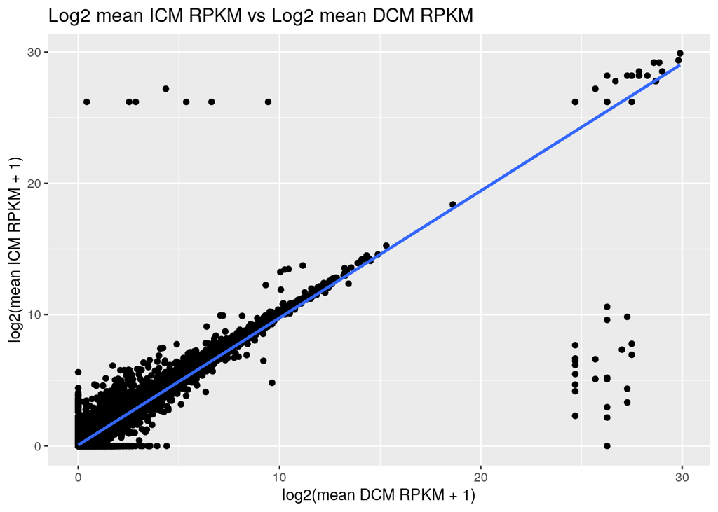

```r
# Get average RPKM in each cohort for each gene
dcm <- dplyr::select(expDataMapped, contains("DCM"))
dcmAvgRpkm <- rowMeans(dcm)
expDataMapped$DCM_avg_RPKM <- dcmAvgRpkm

icm <- dplyr::select(expDataMapped, contains("ICM"))
icmAvgRpkm <- rowMeans(icm)
expDataMapped$ICM_avg_RPKM <- icmAvgRpkm

nf <- dplyr::select(expDataMapped, contains("NF"))
nfAvgRpkm <- rowMeans(nf)
expDataMapped$NF_avg_RPKM <- nfAvgRpkm


avgRpkm <- tibble::tibble(DCM = dcmAvgRpkm, ICM = icmAvgRpkm, NF = nfAvgRpkm)

# log(mean RPKM + 1) was used to avoid log of 0

# ICM vs DCM
corIcmDcmPlot <- ggplot2::ggplot(data = avgRpkm, aes(x = log2(DCM + 1), y = log2(ICM + 1))) +
  ggplot2::geom_point() +
  ggplot2::labs(title = "Log2 mean ICM RPKM vs Log2 mean DCM RPKM",
                x = "log2(mean DCM RPKM + 1)",
                y = "log2(mean ICM RPKM + 1)") +
  ggplot2::geom_smooth(method = "lm", se = FALSE)
corIcmDcmPlot
```

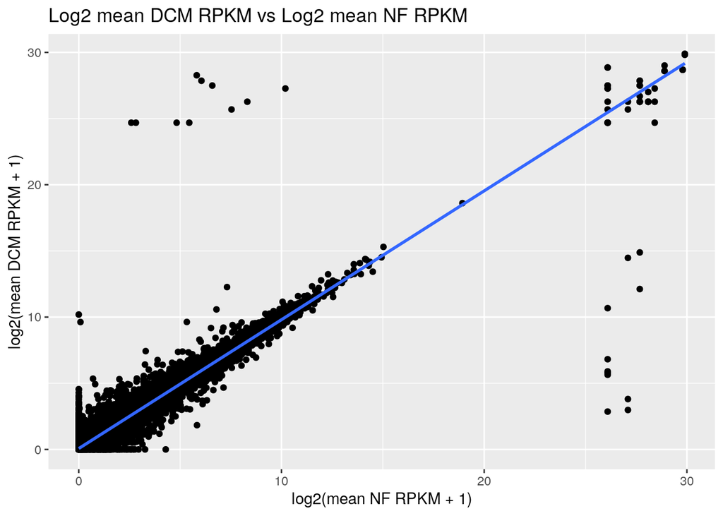

```r
# DCM vs NF
corDcmNfPlot <- ggplot2::ggplot(data = avgRpkm, aes(x = log2(NF + 1), y = log2(DCM + 1))) +
  ggplot2::geom_point() +
  ggplot2::labs(title = "Log2 mean DCM RPKM vs Log2 mean NF RPKM",
                x = "log2(mean NF RPKM + 1)",
                y = "log2(mean DCM RPKM + 1)") +
  ggplot2::geom_smooth(method = "lm", se = FALSE)
corDcmNfPlot
```

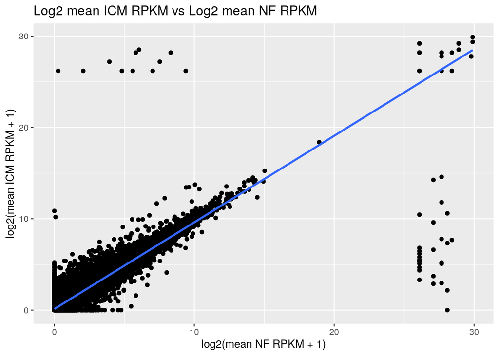

```r
# ICM vs NF
corIcmNfPlot <- ggplot2::ggplot(data = avgRpkm, aes(x = log2(NF + 1), y = log2(ICM + 1))) +
  ggplot2::geom_point() +
  ggplot2::labs(title = "Log2 mean ICM RPKM vs Log2 mean NF RPKM",
                x = "log2(mean NF RPKM + 1)",
                y = "log2(mean ICM RPKM + 1)") +
  ggplot2::geom_smooth(method = "lm", se = FALSE)
corIcmNfPlot
```

These plots show there is a good correlation of the relative magnitude of gene expression between the different samples from different cohorts with some outliers towards the ends.

Due to the large number of replicates, each cohort has their own plot in the following sections.

### Density Plot

Note the log2 is log2(rpkm + 1) to avoid log of 0.

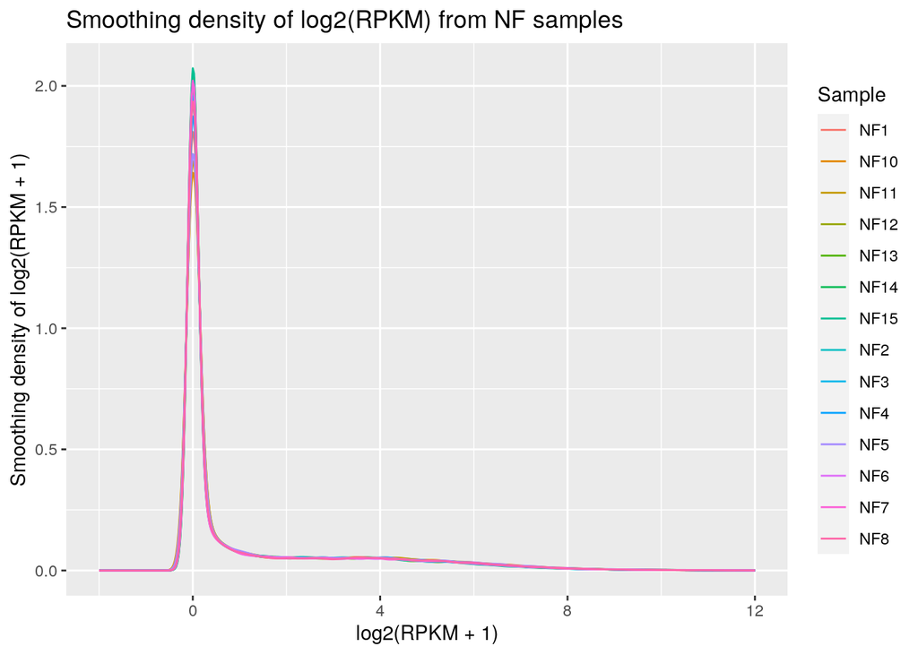

```r
# Only keep the Gene and columns with RPKM for each sample
expDataGeneRpkm <- dplyr::select(expDataMapped, -c(2, 67, 68, 69, 70))
# Need to reshape the data so have Gene, Sample, log2_rpkm as columns
pivotedData <- tidyr::pivot_longer(expDataGeneRpkm, cols = !Gene, names_to = "sample", values_to = "rpkm")
# log2 transform the rpkm column
pivotedData$log2_rpkm <- log2(pivotedData$rpkm + 1) # + 1 to avoid log 0

# Due to the large number of samples each cohort will have their own graph
pivotedData$cohort <- gsub("[0-9]", "", pivotedData$sample)
nfSamples <- dplyr::filter(pivotedData, pivotedData$cohort == "NF")
dcmSamples <- dplyr::filter(pivotedData, pivotedData$cohort == "DCM")
icmSamples <- dplyr::filter(pivotedData, pivotedData$cohort == "ICM")

nfDensityPlot <- ggplot2::ggplot(nfSamples, aes(x=log2_rpkm, color=sample)) +
  ggplot2::geom_density(key_glyph = draw_key_smooth) +
  ggplot2::scale_x_continuous(limits = c(-2, 12)) +
  ggplot2::labs(title = "Smoothing density of log2(RPKM) from NF samples",
                x = "log2(RPKM + 1)",
                y = "Smoothing density of log2(RPKM + 1)",
                color = "Sample")
nfDensityPlot
```

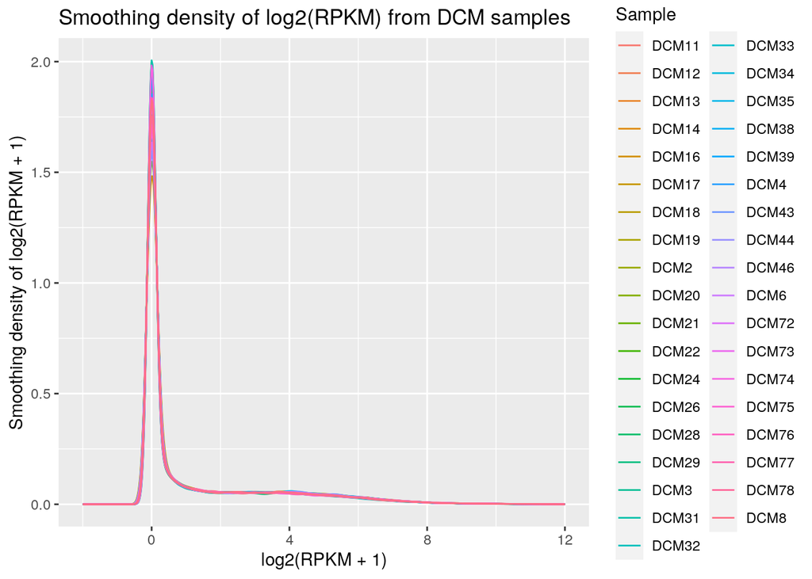

```r
dcmDensityPlot <- ggplot2::ggplot(dcmSamples, aes(x=log2_rpkm, color=sample)) +
  ggplot2::geom_density(key_glyph = draw_key_smooth) +
  scale_x_continuous(limits = c(-2, 12)) +
  ggplot2::labs(title = "Smoothing density of log2(RPKM) from DCM samples",
                x = "log2(RPKM + 1)",
                y = "Smoothing density of log2(RPKM + 1)",
                color = "Sample")
dcmDensityPlot
```

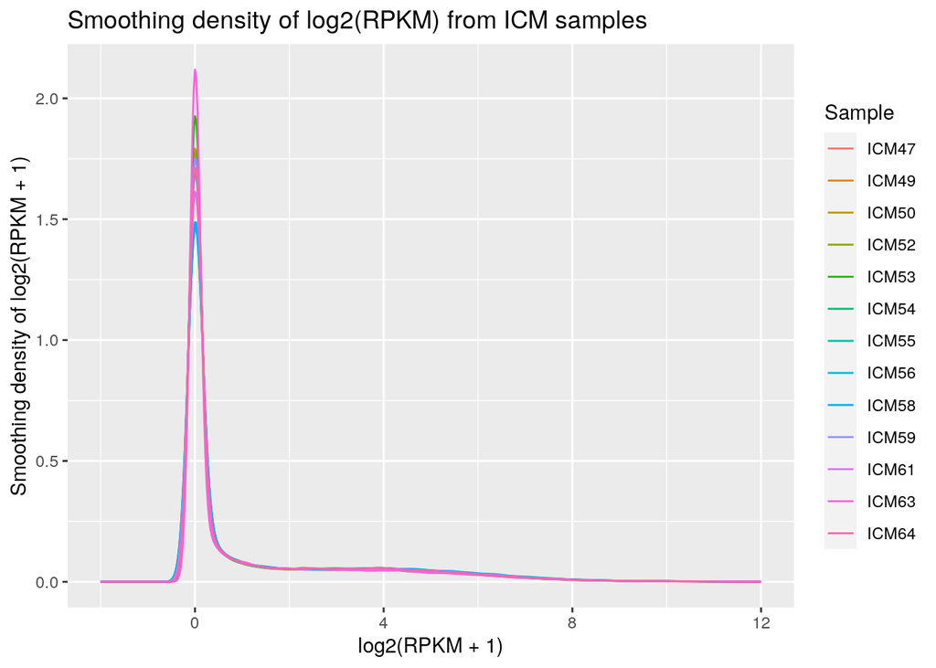

```r
icmDensityPlot <- ggplot2::ggplot(icmSamples, aes(x=log2_rpkm, color=sample)) +
  ggplot2::geom_density(key_glyph = draw_key_smooth) +
  scale_x_continuous(limits = c(-2, 12)) +
  ggplot2::labs(title = "Smoothing density of log2(RPKM) from ICM samples",
                x = "log2(RPKM + 1)",
                y = "Smoothing density of log2(RPKM + 1)",
                color = "Sample")
icmDensityPlot
```

### Boxplot

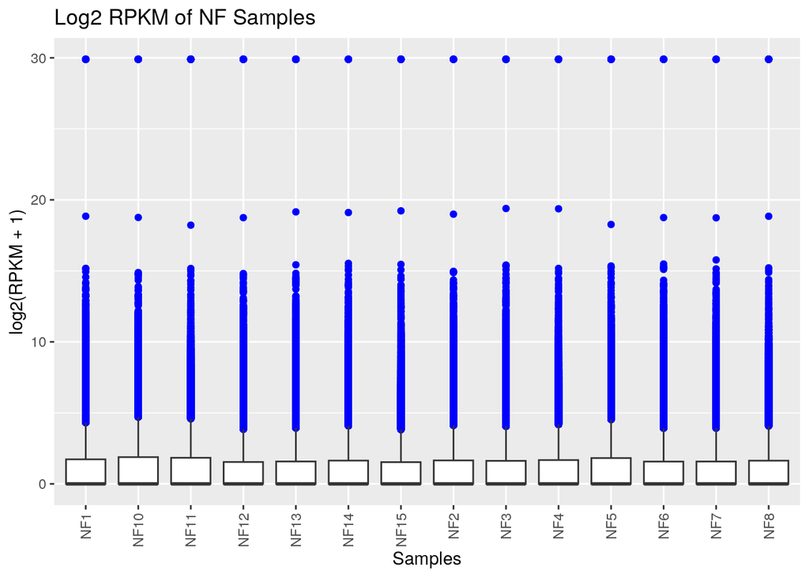

```r
nfBoxPlot <- ggplot2::ggplot(nfSamples, aes(x=sample, y=log2_rpkm)) +
  ggplot2::geom_boxplot(outlier.colour = "blue") +
  ggplot2::theme(axis.text.x = element_text(angle = 90, vjust = 0.5, hjust=1)) +
  ggplot2::labs(title = "Log2 RPKM of NF Samples",
                x = "Samples",
                y = "log2(RPKM + 1)")
nfBoxPlot
```

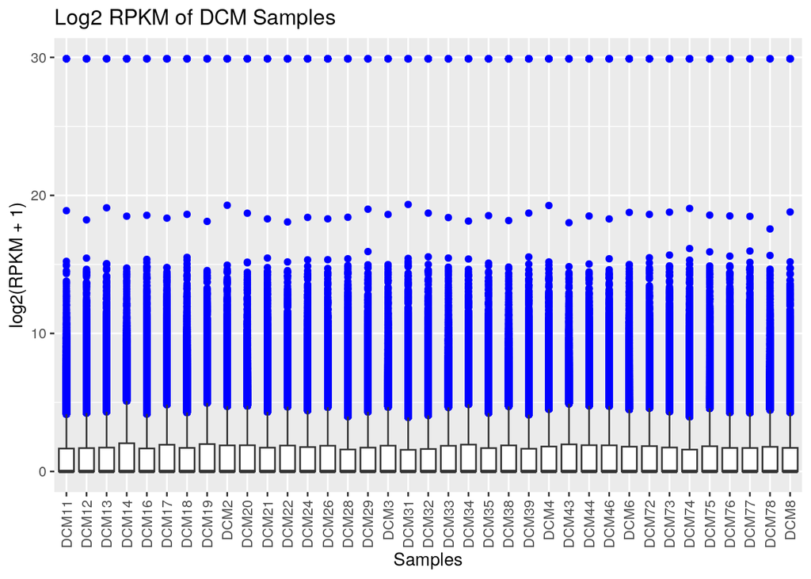

```r
dcmBoxPlot <- ggplot2::ggplot(dcmSamples, aes(x=sample, y=log2_rpkm)) +
  ggplot2::geom_boxplot(outlier.colour = "blue") +
  theme(axis.text.x = element_text(angle = 90, vjust = 0.5, hjust=1)) +
  ggplot2::labs(title = "Log2 RPKM of DCM Samples",
                x = "Samples",
                y = "log2(RPKM + 1)")
dcmBoxPlot
```

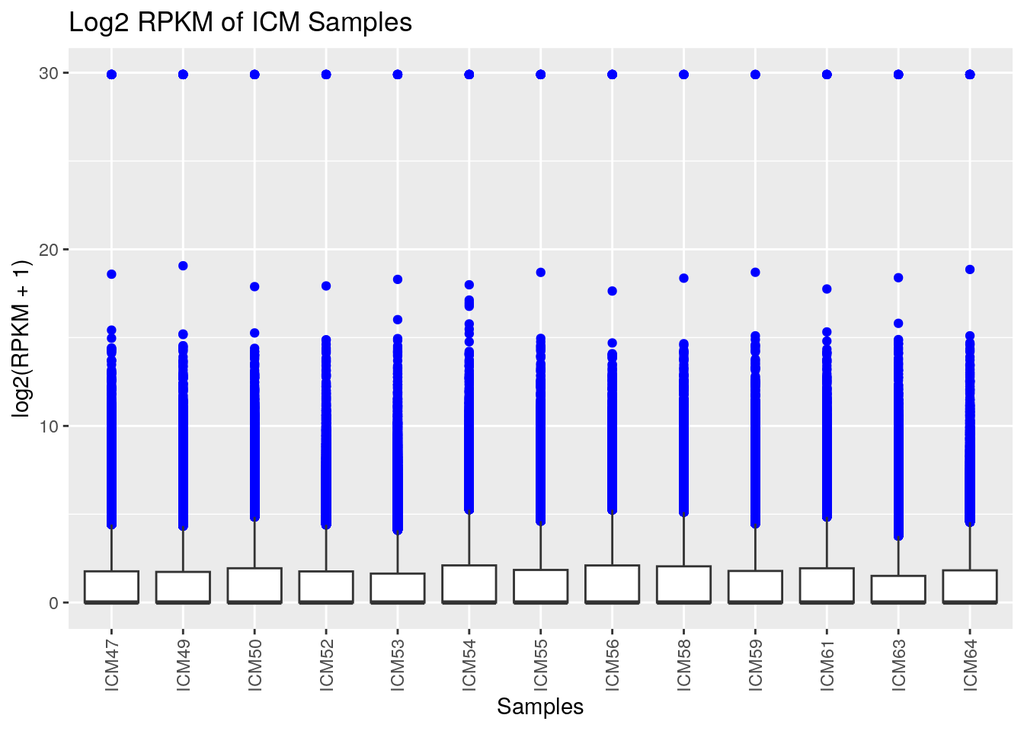

```r
icmBoxPlot <- ggplot2::ggplot(icmSamples, aes(x=sample, y=log2_rpkm)) +
  ggplot2::geom_boxplot(outlier.colour = "blue") +
  theme(axis.text.x = element_text(angle = 90, vjust = 0.5, hjust=1)) +
  ggplot2::labs(title = "Log2 RPKM of ICM Samples",
                x = "Samples",
                y = "log2(RPKM + 1)")
icmBoxPlot
```

Based on the boxplots above, there seem to be many outliers for each sample. As there is no indication they are due to a measurement error they will be kept in this data set. We can’t be sure that these outliers do not represent biological variation. The boxplots show that the median log2(RPKM) is comparable between all samples. It is important to note from these boxplots we are not able to see to what extent specific genes are expressed.

Due to the large number of replicates it is unpractical to do an MA plot for each pair of replicates.

# Normalization

The authors provided the RPKM for this data set so it has been normalized within samples.

An important note, the paper was unclear about was whether or not normalization between samples was performed so this is an exploratory analysis to see if the data has been normalized between samples as well.

We are going to try to normalize via Trimmed Mean of M-values (TMM) and if the pre-normalization graphs look the same as the post normalization graphs then we know the data has been normalized between samples too.

I chose TMM normalization as it normalizes between samples and from the data being in RPKM we know that it has been normalized within samples already. After the normalization factors are calculated I will find the normalized RPKM so it is more comparable to the non-normalized RPKM.

```r
# Extract the cohort and sample number from the original data
cohorts <- gsub("[0-9]", "", colnames(expDataMapped)[3:66])
sampleNum <- gsub("[A-Z]", "", colnames(expDataMapped)[3:66])
samples <- data.frame(cohorts, sampleNum)
rownames(samples) <- colnames(expDataMapped)[3:66]

# Create DGEList object
expDataGeneRpkmMatrix <- dplyr::select(expDataMapped, -c(1, 2, 67, 68, 69, 70))
expDataGeneRpkmMatrix <- as.matrix(sapply(expDataGeneRpkmMatrix, as.numeric))

rownames(expDataGeneRpkmMatrix) <- expDataGeneRpkm$Gene
dgeListObj <- edgeR::DGEList(counts = expDataGeneRpkmMatrix, group = samples$cohorts)

# Calculate normalization factors
dgeObjNorm <- edgeR::calcNormFactors(dgeListObj, method = "TMM")

# Need to get length of the genes before can calculate back to RPKM
geneLengthStash <- "exp_data_gene_lengths.rds"
if (file.exists(geneLengthStash)) {
  geneLengths <- readRDS(geneLengthStash)
} else {
  geneLengths <- biomaRt::getBM(attributes = c("ensembl_gene_id",
                                             "start_position",
                                             "end_position"),
                                          filters = c("ensembl_gene_id"),
                                          values = rownames(expDataGeneRpkmMatrix),
                                          mart = ensembl)
  saveRDS(geneLengths, geneLengthStash)
}
geneLengths$gene_length <- geneLengths$end_position - geneLengths$start_position

normRpkm <- edgeR::rpkm(dgeObjNorm, gene.length = geneLengths$gene_length)
```

Now let’s plot the normalized data. An interpretation of the normalized data and how it compares to the pre-normalized data will follow in the next section titled Comparing pre-normalized and post-normalized data

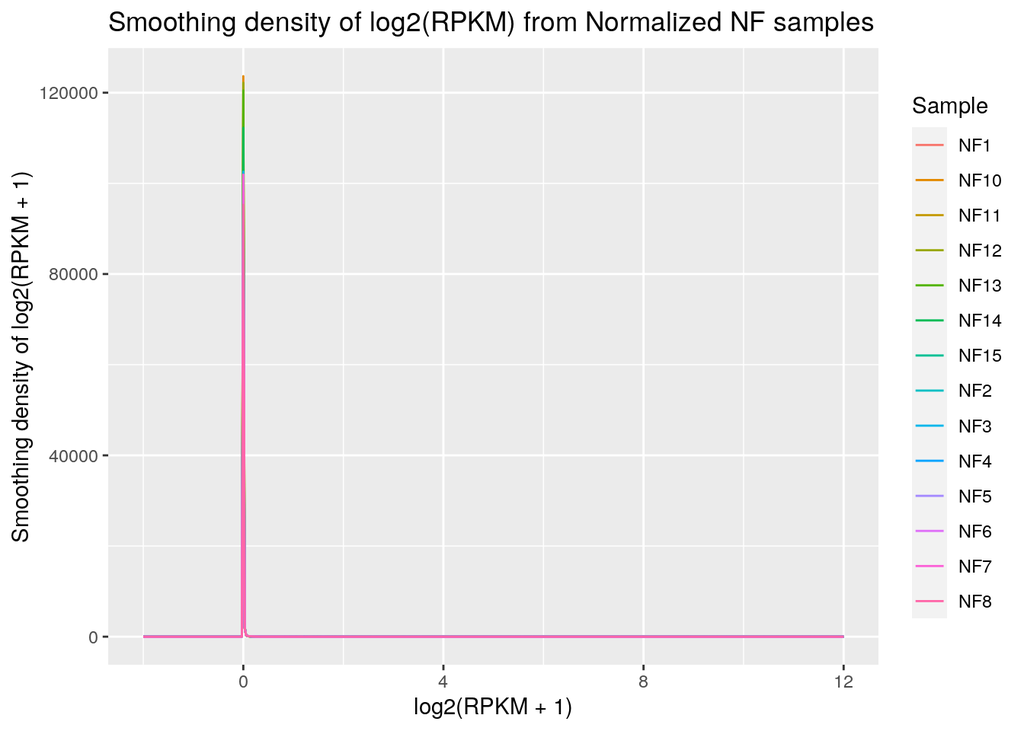

```r
genes <- rownames(normRpkm)
normRpkm <- tibble::as_tibble(normRpkm)
normRpkm$Gene <- genes

normPivotedData <- tidyr::pivot_longer(normRpkm, cols = !Gene, names_to = "sample", values_to = "rpkm")
# log2 transform the rpkm column
normPivotedData$log2_rpkm <- log2(normPivotedData$rpkm + 1) # + 1 to avoid log 0

# Due to the large number of samples each cohort will have their own graph
normPivotedData$cohort <- gsub("[0-9]", "", normPivotedData$sample)
normNfSamples <- dplyr::filter(normPivotedData, normPivotedData$cohort == "NF")
normDcmSamples <- dplyr::filter(normPivotedData, normPivotedData$cohort == "DCM")
normIcmSamples <- dplyr::filter(normPivotedData, normPivotedData$cohort == "ICM")

normNfDenistyPlot <- ggplot2::ggplot(normNfSamples, aes(x=log2_rpkm, color=sample)) +
  ggplot2::geom_density(key_glyph = draw_key_smooth) +
  scale_x_continuous(limits = c(-2, 12)) +
  ggplot2::labs(title = "Smoothing density of log2(RPKM) from Normalized NF samples",
                x = "log2(RPKM + 1)",
                y = "Smoothing density of log2(RPKM + 1)",
                color = "Sample")
normNfDenistyPlot
```

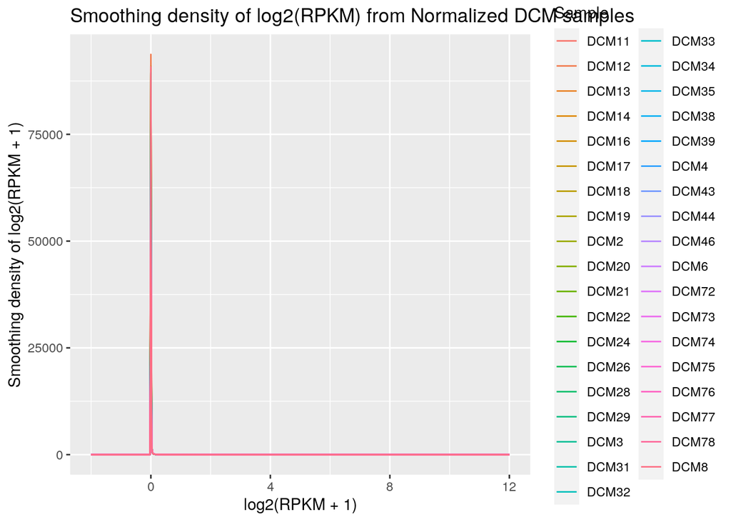

```r
normDcmDenistyPlot <-ggplot2::ggplot(normDcmSamples, aes(x=log2_rpkm, color=sample)) +
  ggplot2::geom_density(key_glyph = draw_key_smooth) +
  scale_x_continuous(limits = c(-2, 12)) +
  ggplot2::labs(title = "Smoothing density of log2(RPKM) from Normalized DCM samples",
                x = "log2(RPKM + 1)",
                y = "Smoothing density of log2(RPKM + 1)",
                color = "Sample")
normDcmDenistyPlot
```

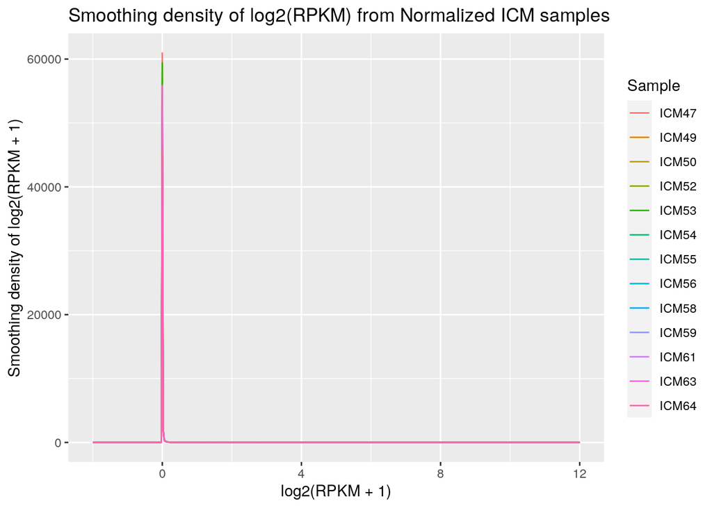

```r
normIcmDenistyPlot <- ggplot2::ggplot(normIcmSamples, aes(x=log2_rpkm, color=sample)) +
  ggplot2::geom_density(key_glyph = draw_key_smooth) +
  scale_x_continuous(limits = c(-2, 12)) +
  ggplot2::labs(title = "Smoothing density of log2(RPKM) from Normalized ICM samples",
                x = "log2(RPKM + 1)",
                y = "Smoothing density of log2(RPKM + 1)",
                color = "Sample")
normIcmDenistyPlot
```

Now we will do a boxplot to compare as well.

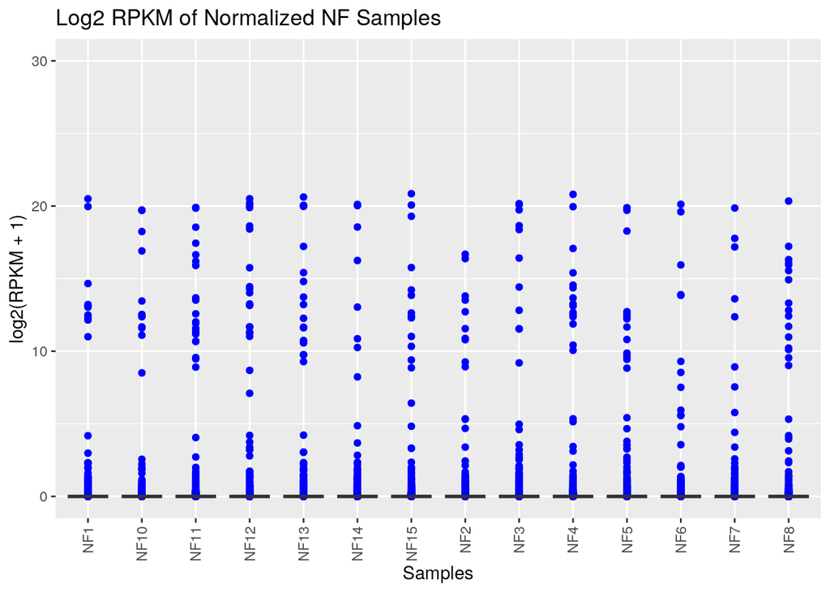

```r
normNfBoxPlot <- ggplot2::ggplot(normNfSamples, aes(x=sample, y=log2_rpkm)) +
  ggplot2::geom_boxplot(outlier.colour = "blue") +
  ggplot2::theme(axis.text.x = element_text(angle = 90, vjust = 0.5, hjust=1)) +
  ggplot2::labs(title = "Log2 RPKM of Normalized NF Samples",
                x = "Samples",
                y = "log2(RPKM + 1)") +
  ggplot2::scale_y_continuous(limits = c(0, 30))
normNfBoxPlot
```

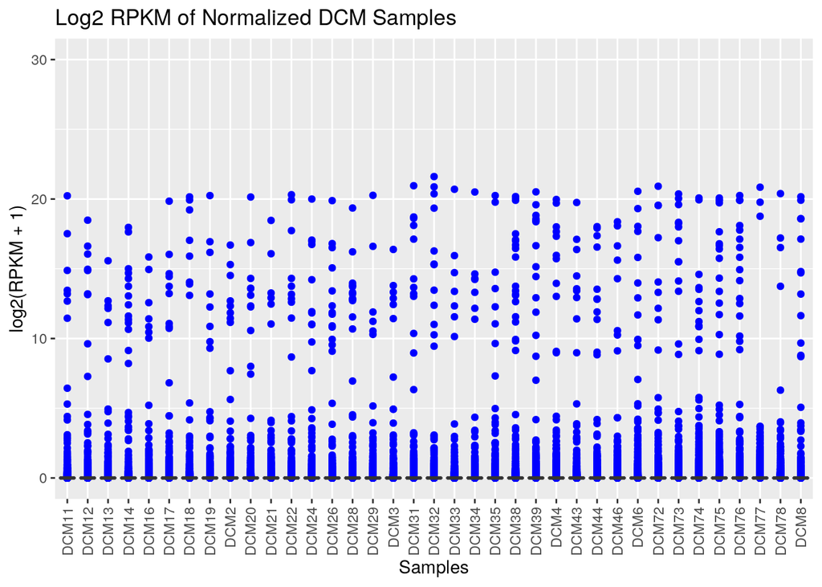

```r
normDcmBoxPlot <- ggplot2::ggplot(normDcmSamples, aes(x=sample, y=log2_rpkm)) +
  ggplot2::geom_boxplot(outlier.colour = "blue") +
  ggplot2::theme(axis.text.x = element_text(angle = 90, vjust = 0.5, hjust=1)) +
  ggplot2::labs(title = "Log2 RPKM of Normalized DCM Samples",
                x = "Samples",
                y = "log2(RPKM + 1)") +
  ggplot2::scale_y_continuous(limits = c(0, 30))
normDcmBoxPlot
```

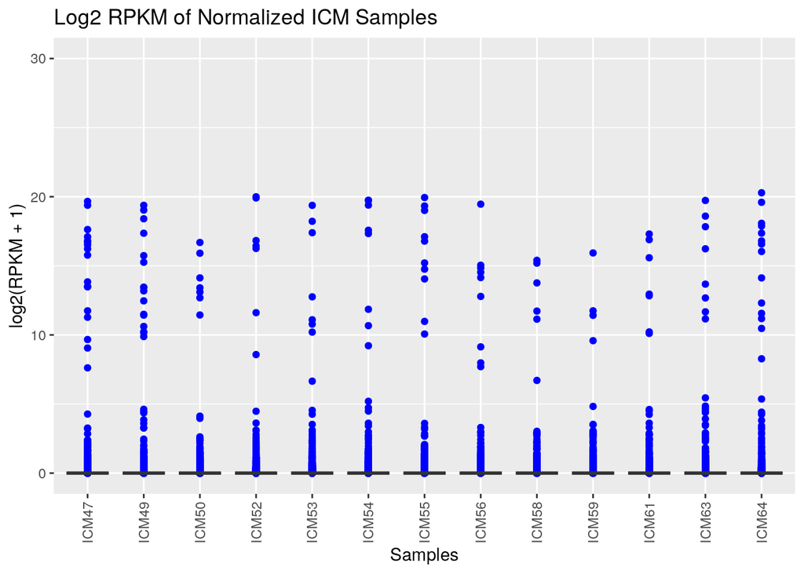

```r
normIcmBoxPlot <- ggplot2::ggplot(normIcmSamples, aes(x=sample, y=log2_rpkm)) +
  ggplot2::geom_boxplot(outlier.colour = "blue") +
  ggplot2::theme(axis.text.x = element_text(angle = 90, vjust = 0.5, hjust=1)) +
  ggplot2::labs(title = "Log2 RPKM of Normalized ICM Samples",
                x = "Samples",
                y = "log2(RPKM + 1)") +
  ggplot2::scale_y_continuous(limits = c(0, 30))
normIcmBoxPlot
```

## Dispersion

Next we will examine how much variance deviates from the mean by looking at the dispersion and the BVC plot:

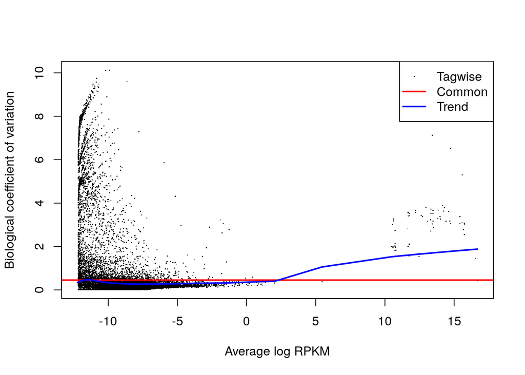

```r
# Note for future analysis the cohorts are more important than which individual sample the data is from
modelDesign <- model.matrix(~samples$cohorts)
dispersion <- edgeR::estimateDisp(dgeObjNorm, modelDesign)
edgeR::plotBCV(dispersion, col.tagwise = "black", col.common = "red", xlab = "Average log RPKM")
```

The BCV plot shows genes above the red line can be considered differentially expressed. We see at the left end of the plot there is a higher degree of variation, this can be explained by genes with lower degrees of expression having higher variation.

We will examine the mean-variance relationship next.

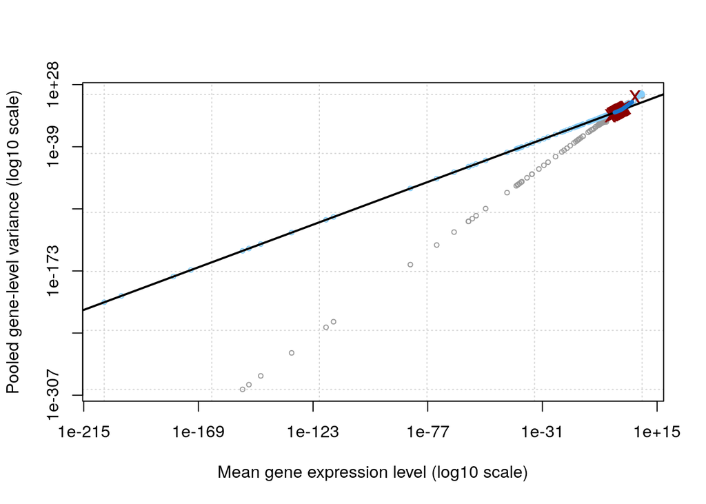

```r
edgeR::plotMeanVar(dispersion,
                   show.raw.vars = TRUE,
                   show.tagwise.vars = TRUE,
                   show.ave.raw.vars = TRUE,
                   NBline = TRUE,
                   show.binned.common.disp.vars = FALSE)
```

From the mean variance plot we see towards the end where the mean gene expression levels are higher there is more overlap between the blue and grey points meaning there are more similar levels of variation at higher levels of gene expression.

Make a MDS plot to examine the distance between samples.

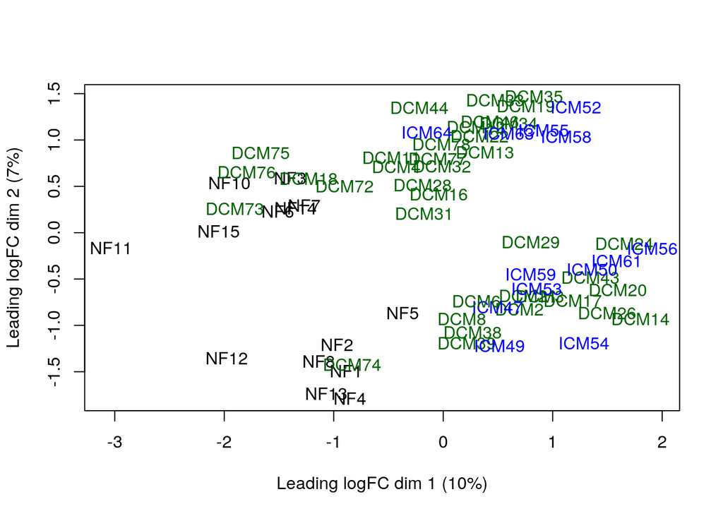

```r
limma::plotMDS(dgeObjNorm, labels=rownames(samples), col = c("darkgreen", "blue")[factor(samples$cohorts)])
```

## Comparing pre-normalized and post-normalized data

Let’s compare the data to the pre-normalized and post-normalized form.

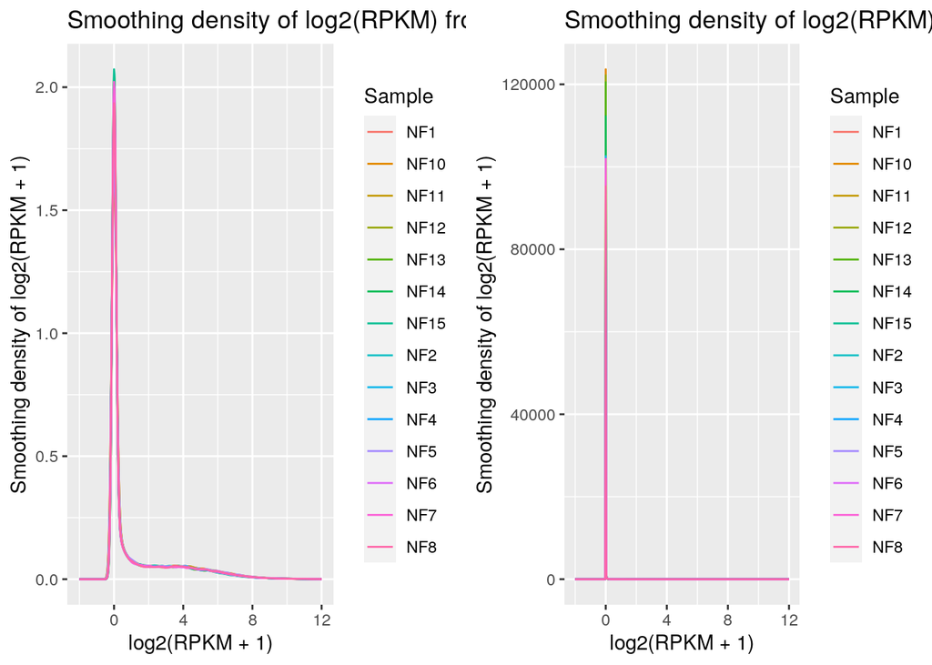

```r
# Compare the density plots
gridExtra::grid.arrange(nfDensityPlot, normNfDenistyPlot, ncol=2)
```

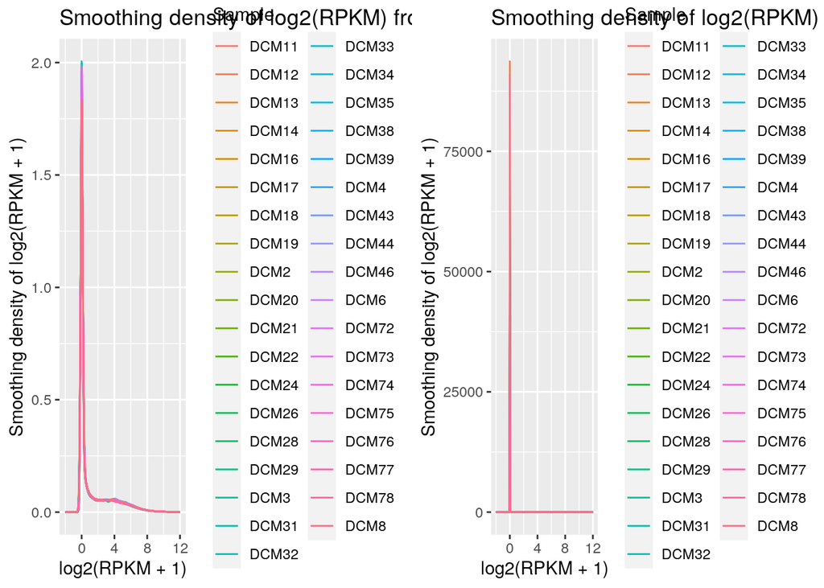

```r
gridExtra::grid.arrange(dcmDensityPlot, normDcmDenistyPlot, ncol=2)
```

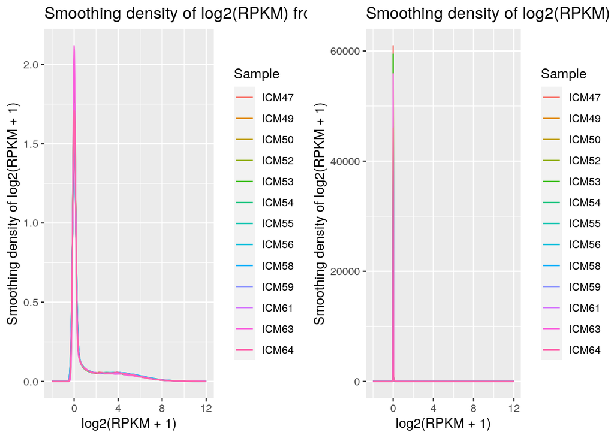

```r
gridExtra::grid.arrange(icmDensityPlot, normIcmDenistyPlot, ncol=2)
```

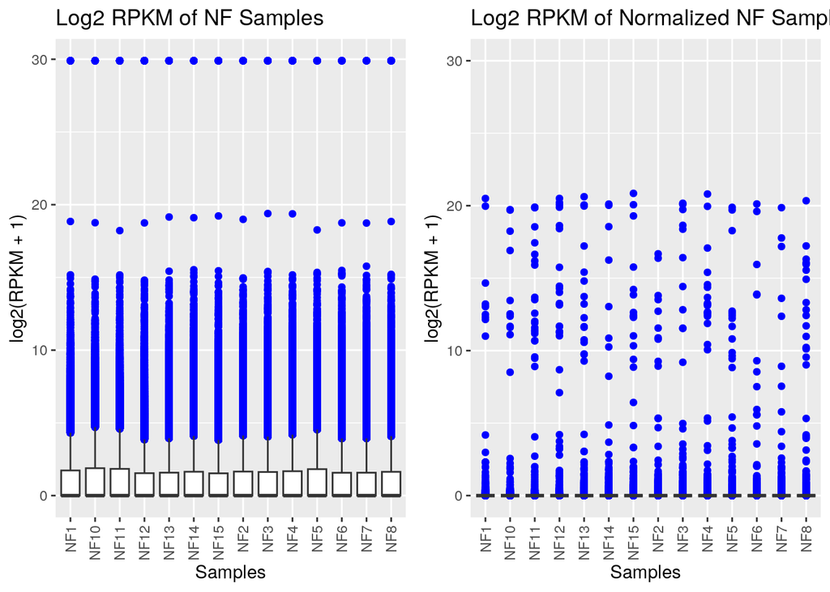

```r
# Compare the boxplots
gridExtra::grid.arrange(nfBoxPlot, normNfBoxPlot, ncol=2)
```

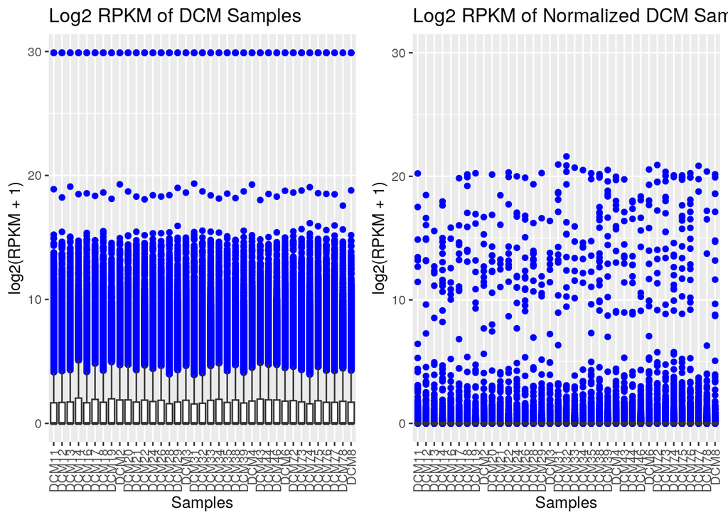

```r
gridExtra::grid.arrange(dcmBoxPlot, normDcmBoxPlot, ncol=2)
```

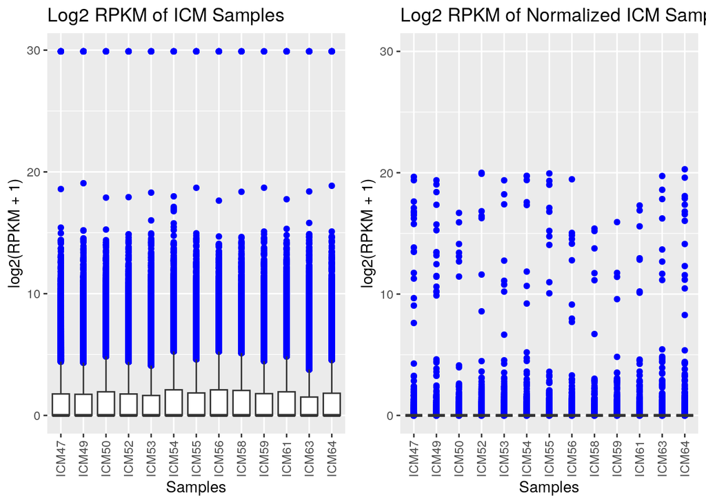

```r
gridExtra::grid.arrange(icmBoxPlot, normIcmBoxPlot, ncol=2)
```

From this we can see the normalized form keeps the same shape as the original data but the values have changed drastically.

In the density plots the y axis scale is very different between pre and post normalized form. I decided to keep the scales different to see how the shapes compare between the two, but it is important to note they are very different. In the pre-normalized density plots the y axis is from 0 to 2.0. While in the normalized NF it is 0 to 120000, in normalized DCM it is 0 to 75000, and in normalized ICM it is 0 to 60000.

We do not want to modify our data so drastically and in addition, in my opinion, the density graph no longer makes sense since the normalized data puts all the reads at essentially the same value. This leaves one big spike instead of a normalized curve which is more similar to what we see in the pre-normalized data.

In the boxplots we see that the outliers with the highest values previously at 30 have been removed and some of the data at the very bottom near 0 have been removed. This makes sense since TMM will remove the upper and lower percentage of data points. The outliers have also become more scattered in the normalized form.

Due to the results seen from the plots after normalization and lack of information in the paper about normalization methods used other than RPKM, it is concluded the data posted is already normalized. Further normalization of this data results in dramatic changes to the data that isn’t desirable.

# Interpretation and Discussion Questions

**1. What are the control and test conditions of the dataset?**

The control of my data set is non-failing hearts (NF). There are two test conditions which are dilated cardiomyopathy (DCM) and ischemic cardiomyopathy (ICM).

**2. Why is the dataset of interest to you?**

This data set is of interest to me, because there is potentially an incomplete understanding of the biological mechanisms contributing to HFrEF. Patients with different etiologies for HFrEF are still receiving relatively the same treatment, even though some have worse prognosis than others like in the case of ICM vs DCM. Heart failure currently affects millions of people and has a 5 year mortality rate of 50%.

**3. Were there expression values that were not unique for specific genes? How did you handle these?**

```r
notUnique <- head(geneCountSummary[which(geneCountSummary > 1)])
length(notUnique)
```

```
## [1] 6
```

**4. Were there expression values that could not be mapped to current HUGO symbols?**

All expression values were able to be mapped to HUGO symbols.

**5. How many outliers were removed?**

Based on the box plots there were many outliers for each sample. I decided to keep them, because we cannot be sure they do not account for biological variation and there’s no indication they are present due to measurement errors or other errors of a similar sort.

**6. How did you handle replicates?**

Since the data is in RPKM it makes it a little difficult to compare across samples. Additionally, the authors did not provide information on further normalization methods used. However, they mentioned in their analysis they considered genes with mean RPKM greater than or equal to 5 across groups to be expressed.

This seems like a reasonable way to remove noise since there are 64 replicates total and lowly expressed genes can be from technical errors or other issues.

Other studies have tried a similar approach where they plotted number of genes past an RPKM threshold vs RPKM (Koch et al. 2018). Below we will do the same to see if that aligns with how the authors chose mean RPKM greater than or equal to 5 as their threshold.

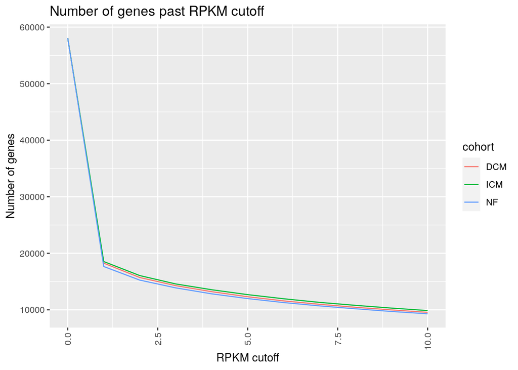

```r
# try rpkm cutoffs 1 to 10
numGenesPastCutoffNf <- c(mode="numeric", length=11) # index corresponds to the cutoff - 1
numGenesPastCutoffDcm <- c(mode="numeric", length=11) # index corresponds to the cutoff - 1
numGenesPastCutoffIcm <- c(mode="numeric", length=11) # index corresponds to the cutoff - 1
for (i in 1:11) {
  numGenesPastCutoffNf[i] <- nrow(dplyr::filter(expDataMapped, NF_avg_RPKM >= i - 1))
  numGenesPastCutoffDcm[i] <- nrow(dplyr::filter(expDataMapped, DCM_avg_RPKM >= i - 1))
  numGenesPastCutoffIcm[i] <- nrow(dplyr::filter(expDataMapped, ICM_avg_RPKM >= i - 1))
}

nfPastCutoffs <- tibble::tibble(cohort = "NF", num = as.numeric(numGenesPastCutoffNf), cutoff = c(0:10))
icmPastCutoffs <- tibble::tibble(cohort = "ICM", num = as.numeric(numGenesPastCutoffIcm), cutoff = c(0:10))
dcmPastCutoffs <- tibble::tibble(cohort = "DCM", num = as.numeric(numGenesPastCutoffDcm), cutoff = c(0:10))

numPastCutoffs <- rbind(nfPastCutoffs, icmPastCutoffs, dcmPastCutoffs)

ggplot2::ggplot(numPastCutoffs, aes(x=cutoff, y=num)) +
  ggplot2::geom_line(aes(color = cohort)) +
  ggplot2::theme(axis.text.x = element_text(angle = 90, vjust = 0.5, hjust=1)) +
  ggplot2::labs(title = "Number of genes past RPKM cutoff",
                x = "RPKM cutoff",
                y = "Number of genes")
```

```r
# Filter the data set to only keep those with mean RPKM >= 5
expDataMapped$all_avg_RPKM <- rowMeans(expDataMapped[3:66])
filteredExpData <- dplyr::filter(expDataMapped, all_avg_RPKM >= 5)
nrow(filteredExpData)
```

```
## [1] 12381
```

**7. What is the final coverage of your dataset?**

The original data set contained 57974 genes and after filtering the genes with low expression, mean RPKM less than 5 across all samples there are 12381 genes left.